```python
import numpy as np
import matplotlib.pyplot as plt
%matplotlib inline
```

# Steve and Dave

### June 2019

Let Steve and Dave be two souls who occupy the same body. This means that they receive identical sensory input, represented here by the function `environment`. We want to study **how Steve and Dave’s emotional philosophies help or hurt them** in coping with their environment’s ups and downs.

Think about `environment` as a composite of all the good and bad things that happen to Steve/Dave. In real life, we are capable of differentiating between different kinds of good and bad, so we recognize a difference between (say) feeling mildly upset in a Prius and crying desparately in a Maserati. But to the extent that these goods and bads balance each other out, we can say that quality of our environment from day to day is basically a random function. Hence, I set up the environment below by simply pulling 4000 values from a normal distribution.

The graph below shows just thirty consecutive samples of `environment`. You can think of these as thirty days, weeks, months, or even years; it doesn’t really matter, as the scale would affect only the variance of the normal distribution and not its underlying randomness.

I won’t even be labeling the *y*-axis, since it is indexing a “high dimensional space” (to borrow [Robin Hanson’s nerdy phrase](https://www.overcomingbias.com/2019/05/expand-vs-fight-social-justice-fertility-bioconservatism-and-ai-risk.html)) that encompasses **all the various things that might contribute to a broad sense of quality**.

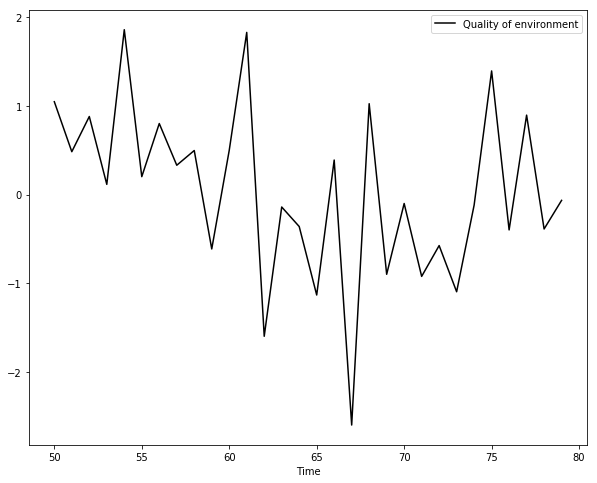

```python
np.random.seed(55555)

environment = np.random.randn(4000)

# Portion to graph
d1 = 50
d2 = 80
t = np.arange(d1,d2)

fig = plt.figure(figsize=(10,8))
ax = fig.add_subplot(111,xlabel="Time",ylabel="")
ax.plot(t,environment[d1:d2],color="black",label="Quality of environment")
ax.legend()
```

The `environment` function shown above represents the *objective* quality of Steve/Dave’s environment at a given moment in time.

But Steve and Dave’s *subjective* experiences of their environment—their moods—also depend on **how their environment is changing**. If things seem to be getting better, their moods pick up; if the quality of the environment consistently decreases while staying above above neutral, Steve and Dave will still feel disappointment.

In this experiment the environment is randomly determined, so regardless of whatever hopes Steve and Dave may have, they cannot predict how the environment will perform in the future. The best they can do is compare how they are feeling *now* with how they’ve been feeling *recently.*

We’ll perform this comparison with the `mood` function. It takes two inputs: `t`, the time; and `d`, the number of recent observations to compare the current environment to.

`mood` computes the (signed) difference between the current `environment` and the average of `environment` over the previous `d` observations.

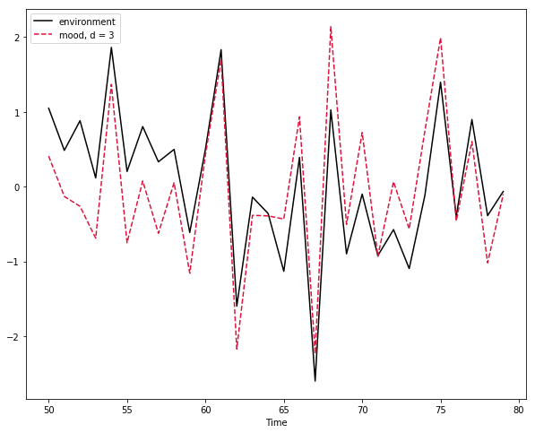

```python
def mood(t,d): return environment[t] - np.mean(environment[t-d:t])

ExampleMoods = np.vectorize(mood)(t,3)

fig = plt.figure(figsize=(10,8))
ax = fig.add_subplot(111,xlabel="Time",ylabel="")
ax.plot(t,environment[d1:d2],color="black",label="environment")
ax.plot(t,ExampleMoods,color="crimson",label="mood, d = 3",ls="dashed")
ax.legend()
```

Perhaps you can see that `mood` is just a really crappy estimate for the derivative of `environment`, one biased highly by the value of `environment` itself. This reflects the fact that people are really bad at assessing their own prospects.

There’s another problem with `mood`, though. It needs to account for the fact that [humans are more sensitive to losses than gains](https://en.wikipedia.org/wiki/Loss_aversion), by a factor that I’m going to ballpark as `3`. Let’s fix that.

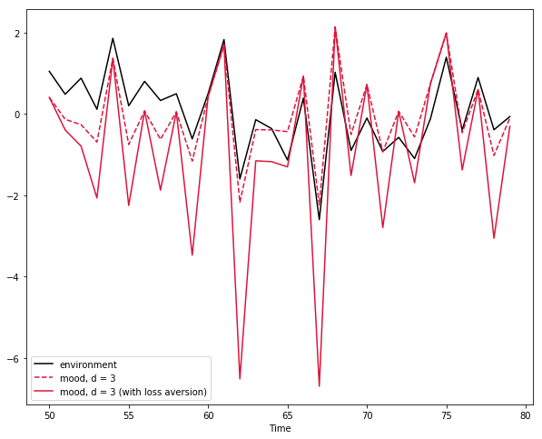

```python
def mood(t,d):
    a = environment[t] - np.mean(environment[t-d:t])
    if a < 0: return 3 * a
    else: return a

ExampleMoods2 = np.vectorize(mood)(t,3)

fig = plt.figure(figsize=(10,8))
ax = fig.add_subplot(111,xlabel="Time",ylabel="")
ax.plot(t,environment[d1:d2],color="black",label="environment")
ax.plot(t,ExampleMoods,color="crimson",label="mood, d = 3",ls="dashed")
ax.plot(t,ExampleMoods2,color="crimson",label="mood, d = 3 (with loss aversion)")
ax.legend()
```

OK, now we can talk about the differences between Steve and Dave’s emotional philosophies. Steve is a sensitive guy. It doesn’t take much to pick him up after a bad day. Dave, for his part, is emotionally disciplined. He’s suspicious of quick rushes and derives happiness only from sustained increases in the quality of his environment—ironic, given that unbeknownst to him, the quality of his environment is determined entirely by chance.

Both Steve and Dave respond primarily to their `environment`. If the environmental quality is good, both will generally feel good. But their subjective feelings are also affecting by their `mood`.

Since Steve is sensitive, a mild positive stimuli yields a generous response in his emotional state. Likewise, a negative interaction that Dave might take in stride can tank Steve’s mood for the rest of the day. In other words, Steve doesn’t search very widely in assessing his `mood`. He just compares how he’s feeling now with the most previous observation.

Dave, by contrast, is emotionally disciplined. In his `mood` function, he takes a longer view than Steve by setting the search paramater to `d = 10`. That is, Dave compares his current mood to the average of his ten most recent moods.

We multiply these adjusted `mood` values by `0.8` to make the graph pretty and add the result to the quality of the `environment` to get Steve and Dave’s subjective `SteveFeelings` and `DaveFeelings`. Hashtag mood.

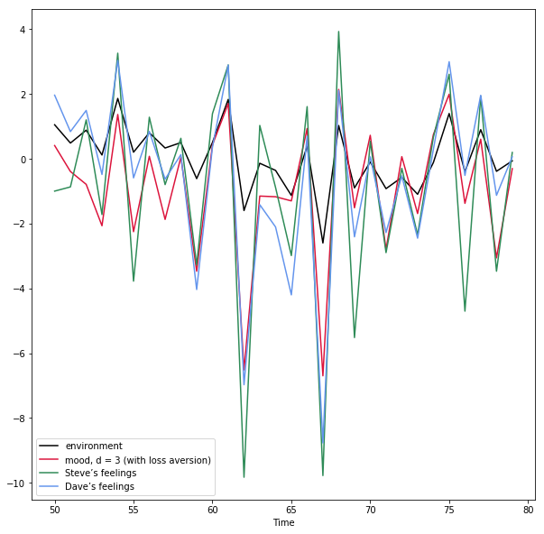

```python
def Steve(t): return environment[t] + 0.8 * mood(t,d = 1)
def Dave(t): return environment[t] + 0.8 * mood(t,d = 10)

SteveFeelings = np.vectorize(Steve)(t)
DaveFeelings = np.vectorize(Dave)(t)

fig = plt.figure(figsize=(10,10))
ax = fig.add_subplot(111,xlabel="Time",ylabel="")
ax.plot(t,environment[d1:d2],color="black",label="environment")
ax.plot(t,ExampleMoods2,color="crimson",label="mood, d = 3 (with loss aversion)")
ax.plot(t,SteveFeelings,color="seagreen",label="Steve’s feelings")
ax.plot(t,DaveFeelings,color="cornflowerblue",label="Dave’s feelings")
ax.legend()
```

As you’d expect, Steve experiences wilder mood swings. His highs are higher and his lows are lower.

But that’s not all. While both Steve and Dave experience loss aversion, Steve’s loss aversion is compounded by his overall moodiness, which means that his higher highs *don’t* cancel out his lower lows. In fact, as the scatter plot below shows, he ends up feeling a lot worse on average.

(Not that Dave is particularly cheery either. The phenomenon of loss aversion guarantees that we’ll always feel bad unless the quality of the environment trends upward over time. This helped a lot with evolution and capitalism.)

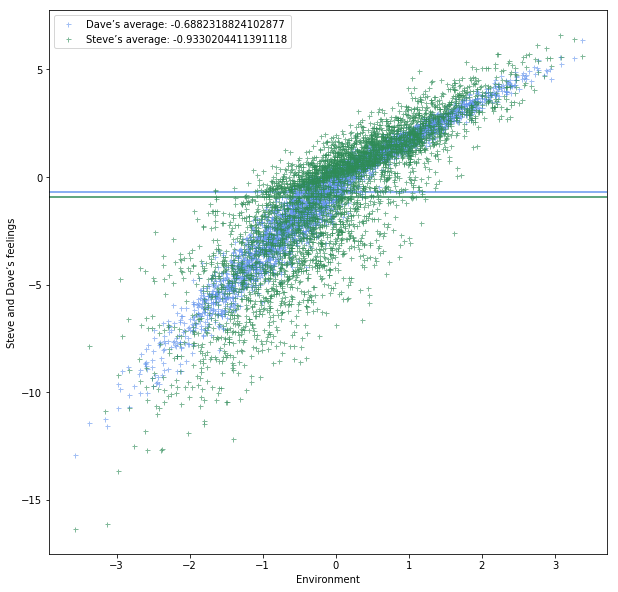

```python
# This time we'll include all 4000 observations.
# You can do even more if you want. It converges on similar averages.

d1 = 11
d2 = 4000

t = np.arange(d1,d2)

SteveFeelings = np.vectorize(Steve)(t)
DaveFeelings = np.vectorize(Dave)(t)

fig = plt.figure(figsize=(10,10))
ax = fig.add_subplot(111,xlabel="Environment",ylabel="Steve and Dave’s feelings")
ax.plot(environment[d1:d2],DaveFeelings,color="cornflowerblue",
        label="Dave’s average: {}".format(np.mean(DaveFeelings)),
        ls="none",markersize=5,marker="+",alpha=0.6)
ax.axhline(y=np.mean(DaveFeelings),color="cornflowerblue")
ax.plot(environment[d1:d2],SteveFeelings,color="seagreen",
        label="Steve’s average: {}".format(np.mean(SteveFeelings)),
        ls="none",markersize=5,marker="+",alpha=0.6)
ax.axhline(y=np.mean(SteveFeelings),color="seagreen")
ax.legend()
```

The upshot is that if you just ask who was feeling better, they are neck and neck. Steve doesn’t have *more* bad days than Dave. His bad days are just *worse.*

```python
# Proportion of observations for which Dave is happier than Steve
sum((DaveFeelings - SteveFeelings) > 0) / len(SteveFeelings)
```

```
0.500877412885435
```

Get the Jupyter Notebook version of this document to play with the code yourself.

I’m at [maxkapur.com](https://www.maxkapur.com/).